# Meu primeiro documento em R Markdown

Fernando Mayer

Agosto, 2016

# 1 Sobre o Markdown

O Markdown é uma linguagem de marcação muito simples, desenvolvida por John Gruber.

A ideia básica por trás da linguagem é fazer com que o escritor se preocupe mais com o **conteúdo** do texto do que com a *formatação*.

Segundo Durbin and Koopman (1997), algumas coisas são como em (Valpine and Hilborn 2005).

Separe multiplas citações com `;`, por exemplo (Buckland et al. 2004; Valpine 2004).

Você pode adicionar comentários arbitrários dentro do colchetes, como por exemplo (veja Durbin and Koopman 1997, 33–35; e Kitagawa 1987, cap. 1).

Remova os colchetes para criar citações no texto com Lele, Dennis, and Lutscher (2007), ou Meinhold and Singpurwalla (2016, 5).

# 2 Mais um título

Aqui vamos tentar descrever uma análise.

# 3 Simulando variáveis aleatórias

No R podemos simular valores de uma distribuição normal
$$f(x;\mu,\sigma^2) = \frac{1}{\sigma\sqrt{2\pi}}
e^{ -\frac{1}{2}\left(\frac{x-\mu}{\sigma}\right)^2 }$$
através da função `rnorm()`.

Seja $X \sim \text{N}(0,1)$, então para gerar 30 valores dessa variável aleatório normal, fazemos

```r
(x <- rnorm(30))
```

```
##  [1] -0.35280288  3.55777203 -0.50097941 -1.03067559 -0.61282646
##  [6] -0.23862253  1.48567053 -0.41736591 -0.58137480 -0.43187967
## [11]  0.44491632 -0.40625549  0.06082181 -0.64067944 -0.91245783
## [16]  0.10948234 -0.57071691  1.09122682 -0.02110860  0.75113225
## [21] -1.17088533 -0.87865824  0.31479681  2.47149072 -1.05612242
## [26]  0.72760987 -0.13008359  0.20837133 -0.71282522 -0.97275504
```

## 3.1 Comentários

Com o resultado dessa simulação, podemos calcular a média e a variância dessa VA $X$ para conferir se o resultado fica próximo de 0 e 1, respectivamente.

Nessa simulação, a média resultou em -0.0138595 e a variância em 1.1255488.

# 4 Visualização

Também podemos fazer um histograma dessa VA $X$ simulada

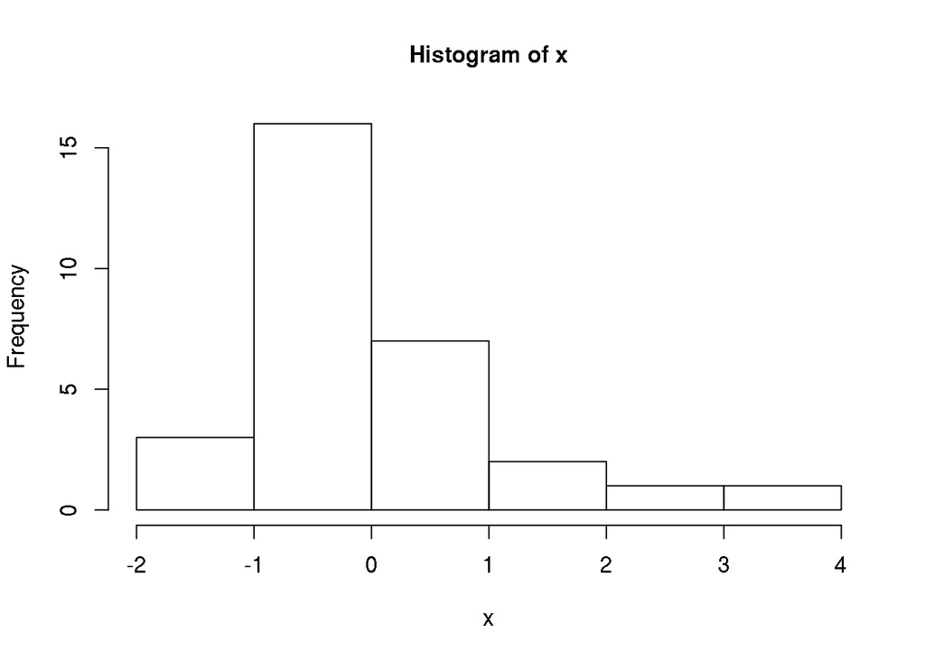

```r
hist(x)
```

# Referências

Buckland, S.T., K.B. Newman, L. Thomas, and N.B. Koesters. 2004. “State-space models for the dynamics of wild animal populations.” *Ecological Modelling* 171 (1-2): 157–75. doi:10.1016/j.ecolmodel.2003.08.002.

Durbin, J., and S. Koopman. 1997. “Monte Carlo maximum likelihood estimation for non-Gaussian state space models.” *Biometrika* 84 (3): 669–84. http://eprints.ucl.ac.uk/18394/.

Kitagawa, G. 1987. “Non-Gaussian State-Space Modeling on Nonstationary Time Series.” *Journal of the American Statistical Association* 82 (400): 1032–63.

Lele, Subhash R, Brian Dennis, and Frithjof Lutscher. 2007. “Data cloning: easy maximum likelihood estimation for complex ecological models using Bayesian Markov chain Monte Carlo methods.” *Ecology Letters* 10 (7): 551–63. doi:10.1111/j.1461-0248.2007.01047.x.

Meinhold, Richard J, and Nozer D Singpurwalla. 2016. “Understanding the Kalman Filter.” *The American Statistician* 37 (2): 123–27.

Valpine, Perry de. 2004. “Monte Carlo State-Space Likelihoods by Weighted Posterior Kernel Density Estimation.” *Journal of the American Statistical Association* 99 (466): 523–36. doi:10.1198/016214504000000476.

Valpine, Perry de, and Ray Hilborn. 2005. “State-space likelihoods for nonlinear fisheries time-series.” *Canadian Journal of Fisheries and Aquatic Sciences* 62 (9). NRC Research Press Ottawa, Canada: 1937–52. doi:10.1139/f05-116.